# PROYECTO FINAL MÓDULO DE R

## Introducción

Las ratios financieros son los indicadores de la situación de la empresa. Son una relación entre unidades financieras, con la que es posible realizar un análisis de la situación o balance económico de la empresa. Se adopta acuerdos a las necesidades concretas para analizar la situación económica para posteriormente mejorar la gestión en la toma de decisiones.

Los cuatro tipos de ratios financieras se clasifican en:

- **Liquidez** que se realiza mediante la suma de dinero disponible en caja, más el dinero pendiente de recibir por los clientes,dividir el pasivo a corto y largo plazo.
- **Gestión** detecta la efectividad y eficiencia en la gestión de las empresas relativas a las ventas al contado, ventas totales, los cobros y gestión de inventarios.
- **Solvencia** se relacionan con un mayor espacio de tiempo entre dos variables: el activo total que se divide con el pasivo total.
- **Rentabilidad** trata de la conexión entre los recursos invertidos y los beneficios generados.

Estos indicadores de valor comprenden diferentes métricas del negocio, en este proyecto destacarán los ratios de liquidez y solvencia.

## Objetivos

- Analizar las ratios comparándolos en función de la situación económicas - financieras de la empresa, dar soluciones concretas acerca de la situación de la empresa.
- Realizar la descripción de los cuatro tipos de indicadores financieros como liquidez, gestión, solvencia y de rentabilidad para comparar a las empresas por su tamaño en función de las ratios financieros.
- Demostrar un dominio competente de las librerías utilizadas en ciencia de datos, mostrando su aplicación efectiva en el análisis y visualización de datos.
- Mostrar un sólido conocimiento y habilidades en el lenguaje de programación R, evidenciado a través de la implementación de código efectivo y eficiente para manipular datos, realizar análisis estadísticos y crear visualizaciones gráficas.

## Descripción de los datos

### Lectura de Librerías

Para el análisis de este proyecto se han cargado las siguientes librerías:

- **readxl**: Paquete que facilita la transferencia de datos de Excel a R.
- tidyr: Es un paquete que nos ayuda a simplificar el proceso de creación de datos ordenados.
- **ggplot2**: Sistema organizado de visualización de datos.
- **tidyverse**: Es una colección de paquetes disponibles en R y orientados a la manipulación, importación, exploración y visualización de datos. Está compuesto de los siguientes paquetes: readr, dplyr, ggplot2, tibble, tidyr, purr, stringr, focats.
- **dplyr**: Paquete que proporciona una grámatica de manipulación de datos y proporciona los verbos más utilizados que ayudan a los análisis de ciencia de datos a resolver la manipulación de datos más común.

### Tratamiento de la base

Las bases de datos proporcionadas son 4 en formato xlsx .

- **Balances_2014**: Contiene información correspondiente a balances de varias empresas, se describre su situación, país, provincia, activos fijos, pasivos, entre otros.
- **cias_codebook**: Diccionario
- **ciiu**: Listado de actividades económicas con su respectivo nivel
- **Formulario 102**: Documento de la declaración del impuesto a la renta personas naturales y sucesiones invisas obligadas a llevar contabilidad (SRI)

Una vez cargadas las librerias, se prosigue con la lectura de los datos.

```r
balances_2014 <- read_excel("Data/balances_2014.xlsx")
balances_2014
```

```
## # A tibble: 47,033 × 347
##    expediente ruc         nombre_cia situacion tipo  fecha_const pais  provincia
##         <dbl> <chr>       <chr>      <chr>     <chr> <chr>       <chr> <chr>
##  1          1 1790013731… ACEITES T… ACTIVA    ANÓN… 20/07/1951  ECUA… SANTO DO…
##  2          2 1790004724… ACERIA DE… ACTIVA    ANÓN… 17/12/1963  ECUA… PICHINCHA
##  3          3 1790008959… ACERO COM… ACTIVA    ANÓN… 27/06/1957  ECUA… PICHINCHA
##  4         11 1790044149… AEROVIAS … ACTIVA    SUCU… 27/09/1965  COLO… PICHINCHA
##  5         21 1790022900… AGENCIAS … ACTIVA    ANÓN… 23/09/1954  ECUA… PICHINCHA
##  6         22 1790023516… AGENCIAS … ACTIVA    ANÓN… 08/07/1963  ECUA… PICHINCHA
##  7         41 1790046400… AIR FRANC… ACTIVA    SUCU… 14/01/1965  FRAN… PICHINCHA
##  8         49 1790036391… ALMACENES… ACTIVA    ANÓN… 23/03/1936  ECUA… PICHINCHA
##  9         58 1790017508… DESEDUSA … ACTIVA    ANÓN… 02/05/1951  ECUA… PICHINCHA
## 10         63 1790084604… CONFITECA… ACTIVA    ANÓN… 21/10/1963  ECUA… PICHINCHA
## # ℹ 47,023 more rows
## # ℹ 339 more variables: canton <chr>, ciudad <chr>, ciiu4_nivel1 <chr>,
## #   ciiu4_nivel6 <chr>, trab_direc <dbl>, trab_admin <dbl>, trab_produc <dbl>,
## #   trab_otros <dbl>, tamanio <chr>, anio <dbl>, v311 <dbl>, v312 <dbl>,
## #   v313 <dbl>, v314 <dbl>, v315 <dbl>, v316 <dbl>, v317 <dbl>, v318 <dbl>,
## #   v319 <dbl>, v320 <dbl>, v321 <dbl>, v322 <dbl>, v323 <dbl>, v324 <dbl>,
## #   v325 <dbl>, v326 <dbl>, v327 <dbl>, v328 <dbl>, v329 <dbl>, v330 <dbl>, …
```

```r
#cias_codebook <- read_excel("Data/cias_codebook.xlsx")
#ciiu <- read_excel("Data/ciiu.xlsx")
#Formulario_102 <- read_excel("Data/Formulario 102.xls")
```

Utilizando los datos en el archivo llamado balance 2014 se generó un tibble, posterior se reduce la dimensión de la base con variables pedidas en el proyecto.

```r
empresas<-tibble::as_tibble(balances_2014)
empresas_1<- empresas %>%  mutate(LiquidezCorriente= (v345/v539),
                                   EndeudamientoActivo= (v599/v499),
                                   EndeudamientoPatrimonial= (v599/v698),
                                   EndeudamientoActivoFijo= (v698/v498),
                                   Apalancamiento= (v499/v698))  %>%
                            select(Empresas=nombre_cia,
                                   Status=situacion,
                                   TipoEmpresa = tipo,
                                   Pais=pais,
                                   Provincia=provincia,
                                   Canton=canton,
                                   Ciudad=ciudad,
                                   Actividad_economica=ciiu4_nivel1,
                                   SubActividad=ciiu4_nivel6,
                                   LiquidezCorriente,
                                   EndeudamientoActivo,
                                   EndeudamientoPatrimonial,
                                   EndeudamientoActivoFijo,
                                   Apalancamiento,
                                   fecha_const)
empresas_1
```

```
## # A tibble: 47,033 × 15
##    Empresas Status TipoEmpresa Pais  Provincia Canton Ciudad Actividad_economica
##    <chr>    <chr>  <chr>       <chr> <chr>     <chr>  <chr>  <chr>
##  1 ACEITES… ACTIVA ANÓNIMA     ECUA… SANTO DO… SANTO… SANTO… A
##  2 ACERIA … ACTIVA ANÓNIMA     ECUA… PICHINCHA QUITO  QUITO  C
##  3 ACERO C… ACTIVA ANÓNIMA     ECUA… PICHINCHA QUITO  QUITO  G
##  4 AEROVIA… ACTIVA SUCURSAL  … COLO… PICHINCHA QUITO  QUITO  H
##  5 AGENCIA… ACTIVA ANÓNIMA     ECUA… PICHINCHA QUITO  QUITO  G
##  6 AGENCIA… ACTIVA ANÓNIMA     ECUA… PICHINCHA QUITO  QUITO  G
##  7 AIR FRA… ACTIVA SUCURSAL  … FRAN… PICHINCHA QUITO  QUITO  H
##  8 ALMACEN… ACTIVA ANÓNIMA     ECUA… PICHINCHA QUITO  QUITO  G
##  9 DESEDUS… ACTIVA ANÓNIMA     ECUA… PICHINCHA QUITO  QUITO  P
## 10 CONFITE… ACTIVA ANÓNIMA     ECUA… PICHINCHA QUITO  QUITO  C
## # ℹ 47,023 more rows
## # ℹ 7 more variables: SubActividad <chr>, LiquidezCorriente <dbl>,
## #   EndeudamientoActivo <dbl>, EndeudamientoPatrimonial <dbl>,
## #   EndeudamientoActivoFijo <dbl>, Apalancamiento <dbl>, fecha_const <chr>
```

Esta nueva base de datos estará conformada por las siguientes variables:

- Empresas: variable que contiene los nombres de las compañías
- Status: variable que especifica la situación de la compañía ( activa, en liquidación, etc)
- Tipo_de_empresa: variable que contiene la clase de compañía analizada (anónima, economía mixta, etc)
- País
- Provincia
- Cantón
- Ciudad
- Actividad económica: variable que contiene la descripción del código CIIU4 NIVEL
- Subactividad: variable que contiene la descripción del código CIIU4 NIVEL 6
- Liquidez corriente: Indicador financiero que se compone de la siguiente forma:

$$Liquidez_Corriente=\frac{Activo_Corriente}{Pasivo_Corriente}$$

- Endeudamiento del activo:

$$Endeudamiento_Activo=\frac{Pasivo}{Activo}$$

- Endeudamiento patrimonial:
  $$Endeudamiento_Patrimonial=\frac{Pasivo}{Patrimonio}$$
- Endeudamiento del Activo Fijo:

$$Endeudamiento_Activo_Fijo=\frac{Patrimonio}{Activo_No_Corriente}$$

- Apalancamiento:

$$Apalancamiento=\frac{Activo}{Patrimonio}$$

### Análisis exploratorio de datos

Una vez se analizó la composición de variables, procedemos a explorar los datos

```r
glimpse(empresas_1)
```

```
## Rows: 47,033
## Columns: 15
## $ Empresas                 <chr> "ACEITES TROPICALES SOCIEDAD ANONIMA ATSA", "…
## $ Status                   <chr> "ACTIVA", "ACTIVA", "ACTIVA", "ACTIVA", "ACTI…
## $ TipoEmpresa              <chr> "ANÓNIMA", "ANÓNIMA", "ANÓNIMA", "SUCURSAL  E…
## $ Pais                     <chr> "ECUADOR", "ECUADOR", "ECUADOR", "COLOMBIA", …
## $ Provincia                <chr> "SANTO DOMINGO DE LOS TSACHILAS", "PICHINCHA"…
## $ Canton                   <chr> "SANTO DOMINGO", "QUITO", "QUITO", "QUITO", "…
## $ Ciudad                   <chr> "SANTO DOMINGO", "QUITO", "QUITO", "QUITO", "…
## $ Actividad_economica      <chr> "A", "C", "G", "H", "G", "G", "H", "G", "P", …
## $ SubActividad             <chr> "A0126.01", "C2410.25", "G4663.13", "H5110.01…
## $ LiquidezCorriente        <dbl> 3.15925400, 1.83329981, 3.08762824, 0.9824562…
## $ EndeudamientoActivo      <dbl> 0.04552082, 0.57575229, 0.67680185, 1.0178570…
## $ EndeudamientoPatrimonial <dbl> 0.04769179, 1.35711351, 2.09407713, -57.00021…
## $ EndeudamientoActivoFijo  <dbl> 0.9962363, 1.1156390, 3.3943681, -Inf, 7.5131…
## $ Apalancamiento           <dbl> 1.047692, 2.357114, 3.094077, -56.000219, 1.8…
## $ fecha_const              <chr> "20/07/1951", "17/12/1963", "27/06/1957", "27…
```

```r
empresas_1$Status<- as.factor(empresas_1$Status)
empresas_1$TipoEmpresa<- as.factor(empresas_1$TipoEmpresa)
empresas_1$Actividad_economica<- as.factor(empresas_1$Actividad_economica)
empresas_1$SubActividad<- as.factor(empresas_1$SubActividad)#convertir a factor
glimpse(empresas_1)
```

```
## Rows: 47,033
## Columns: 15
## $ Empresas                 <chr> "ACEITES TROPICALES SOCIEDAD ANONIMA ATSA", "…
## $ Status                   <fct> ACTIVA, ACTIVA, ACTIVA, ACTIVA, ACTIVA, ACTIV…
## $ TipoEmpresa              <fct> ANÓNIMA, ANÓNIMA, ANÓNIMA, SUCURSAL  EXTRANJE…
## $ Pais                     <chr> "ECUADOR", "ECUADOR", "ECUADOR", "COLOMBIA", …
## $ Provincia                <chr> "SANTO DOMINGO DE LOS TSACHILAS", "PICHINCHA"…
## $ Canton                   <chr> "SANTO DOMINGO", "QUITO", "QUITO", "QUITO", "…
## $ Ciudad                   <chr> "SANTO DOMINGO", "QUITO", "QUITO", "QUITO", "…
## $ Actividad_economica      <fct> A, C, G, H, G, G, H, G, P, C, C, I, G, C, G, …
## $ SubActividad             <fct> A0126.01, C2410.25, G4663.13, H5110.01, G4649…
## $ LiquidezCorriente        <dbl> 3.15925400, 1.83329981, 3.08762824, 0.9824562…
## $ EndeudamientoActivo      <dbl> 0.04552082, 0.57575229, 0.67680185, 1.0178570…
## $ EndeudamientoPatrimonial <dbl> 0.04769179, 1.35711351, 2.09407713, -57.00021…
## $ EndeudamientoActivoFijo  <dbl> 0.9962363, 1.1156390, 3.3943681, -Inf, 7.5131…
## $ Apalancamiento           <dbl> 1.047692, 2.357114, 3.094077, -56.000219, 1.8…
## $ fecha_const              <chr> "20/07/1951", "17/12/1963", "27/06/1957", "27…
```

Con el propósito de obtener una comprensión más profunda de los datos, procedimos a calcular los estadísticos de las variables numéricas. Para tal fin, empleamos el comando summary(), el cual nos proporciona estadísticas descriptivas como los valores mínimo y máximo, los cuartiles y el promedio.

```r
summary(empresas_1)
```

```
##    Empresas                                                Status
##  Length:47033       ACTIVA                                    :42891
##  Class :character   DISOLUC. LIQUIDAC. OFICIO INSC. EN RM     : 2788
##  Mode  :character   DISOLUC. LIQUIDAC. OFICIO NO INSC. EN RM  :  683
##                     DISOLUC. Y LIQUIDAC. ANTIC. INSCR. RM     :  316
##                     DISOLUC. Y LIQUIDAC. ANTIC. NO INSC. EN RM:  136
##                     LIQUIDAC. DE PLENO DERECHO INSC. RM       :   81
##                     (Other)                                   :  138
##                        TipoEmpresa        Pais            Provincia
##  ANÓNIMA                     :32793   Length:47033       Length:47033
##  ANÓNIMA  EN PREDIOS RÚSTICOS:   18   Class :character   Class :character
##  ANÓNIMA MULTINACIONAL ANDINA:    4   Mode  :character   Mode  :character
##  ASOCIACIÓN O CONSORCIO      :   21
##  ECONOMÍA MIXTA              :   13
##  RESPONSABILIDAD LIMITADA    :13740
##  SUCURSAL  EXTRANJERA        :  444
##     Canton             Ciudad          Actividad_economica   SubActividad
##  Length:47033       Length:47033       G      :11717       L6810.01: 5053
##  Class :character   Class :character   H      : 5445       H4923.01: 2962
##  Mode  :character   Mode  :character   L      : 5385       F4100.10: 1780
##                                        M      : 5095       M7020.04:  676
##                                        F      : 4024       A0321.02:  672
##                                        C      : 3661       G4530.00:  645
##                                        (Other):11706       (Other) :35245
##  LiquidezCorriente EndeudamientoActivo EndeudamientoPatrimonial
##  Min.   : 0.000    Min.   :0.0000      Min.   :-9001.123
##  1st Qu.: 1.026    1st Qu.:0.1148      1st Qu.:    0.017
##  Median : 1.862    Median :0.5681      Median :    0.900
##  Mean   :   Inf    Mean   :   Inf      Mean   :      Inf
##  3rd Qu.:11.001    3rd Qu.:0.8625      3rd Qu.:    3.936
##  Max.   :   Inf    Max.   :   Inf      Max.   :      Inf
##  NA's   :1631      NA's   :959         NA's   :951
##  EndeudamientoActivoFijo Apalancamiento      fecha_const
##  Min.   :   -Inf         Min.   :-9000.123   Length:47033
##  1st Qu.:  0.539         1st Qu.:    1.017   Class :character
##  Median :  1.579         Median :    1.900   Mode  :character
##  Mean   :    NaN         Mean   :      Inf
##  3rd Qu.:875.503         3rd Qu.:    4.936
##  Max.   :    Inf         Max.   :      Inf
##  NA's   :975             NA's   :951
```

### Datos Faltantes

En la sección anterior, hemos observado que las variables Liquidez Corriente, EndeudamientoActivo, EndeudamientoPatrimonial, EndeudamientoActivoFijo y Apalancamiento contienen valores perdidos, también conocidos como NAs, así como datos con información +-INF. Estos valores pueden generar errores, especialmente en funciones estadísticas que agrupan datos para obtener resultados.

En este proyecto, hemos decidido omitir este tipo de datos debido a que el porcentaje de valores faltantes no supera el 80%. Su análisis no afecta significativamente el resultado, lo que justifica su exclusión del análisis para mantener la integridad y precisión de los resultados obtenidos.

| LiquidezCorriente | EndeudamientoActivo | EndeudamientoPatrimonial |
| --- | --- | --- |
| Datos NAs | Datos NAs | Datos NAs |
| 3,47 % % | 2,04 % | 2,02 % |

| EndeudamientoActivoFijo | Apalancamiento |
| --- | --- |
| Datos NAs | Datos NAs |
| 2,07 % | 2,02 % |

El código siguiente realiza una transformación de los datos, convirtiendo los valores -Inf y +Inf en NAs. Posteriormente, se utiliza la función drop_na() para eliminar completamente los datos con valores faltantes de nuestra base de datos.

```r
#quitar datos -Inf y +Inf
quitar_inf <- function(dataframe, columnas_numericas) {
  # Iterar sobre las columnas numéricas y reemplazar los -Inf y +Inf con NA
  for (col in columnas_numericas) {
    dataframe[[col]][dataframe[[col]] == -Inf | dataframe[[col]] == Inf] <- NA
  }

  return(dataframe)
}
columnas_a_limpiar <- c("LiquidezCorriente", "EndeudamientoActivo","EndeudamientoPatrimonial",
                        "EndeudamientoActivoFijo", "Apalancamiento")
empresas_2 <- quitar_inf(empresas_1, columnas_a_limpiar)

#borrar NAs
empresas_3 <- empresas_2 %>% drop_na()
summary(empresas_3)
```

```
##    Empresas                                                Status
##  Length:31123       ACTIVA                                    :29095
##  Class :character   DISOLUC. LIQUIDAC. OFICIO INSC. EN RM     : 1511
##  Mode  :character   DISOLUC. LIQUIDAC. OFICIO NO INSC. EN RM  :  315
##                     DISOLUC. Y LIQUIDAC. ANTIC. INSCR. RM     :   79
##                     DISOLUC. Y LIQUIDAC. ANTIC. NO INSC. EN RM:   40
##                     LIQUIDAC. DE PLENO DERECHO INSC. RM       :   37
##                     (Other)                                   :   46
##                        TipoEmpresa        Pais            Provincia
##  ANÓNIMA                     :20932   Length:31123       Length:31123
##  ANÓNIMA  EN PREDIOS RÚSTICOS:   17   Class :character   Class :character
##  ANÓNIMA MULTINACIONAL ANDINA:    3   Mode  :character   Mode  :character
##  ASOCIACIÓN O CONSORCIO      :   10
##  ECONOMÍA MIXTA              :   11
##  RESPONSABILIDAD LIMITADA    : 9914
##  SUCURSAL  EXTRANJERA        :  236
##     Canton             Ciudad          Actividad_economica   SubActividad
##  Length:31123       Length:31123       G      :8210        L6810.01: 3230
##  Class :character   Class :character   L      :3439        H4923.01: 1280
##  Mode  :character   Mode  :character   M      :3296        F4100.10: 1079
##                                        C      :2799        A0321.02:  512
##                                        H      :2773        G4530.00:  501
##                                        F      :2407        M7020.04:  447
##                                        (Other):8199        (Other) :24074
##  LiquidezCorriente   EndeudamientoActivo EndeudamientoPatrimonial
##  Min.   :      0.0   Min.   :  0.0000    Min.   :-9001.12
##  1st Qu.:      0.9   1st Qu.:  0.3800    1st Qu.:    0.40
##  Median :      1.4   Median :  0.6724    Median :    1.58
##  Mean   :     55.6   Mean   :  0.7714    Mean   :   23.60
##  3rd Qu.:      2.8   3rd Qu.:  0.8862    3rd Qu.:    5.26
##  Max.   :1038192.0   Max.   :568.7887    Max.   :84392.41
##
##  EndeudamientoActivoFijo Apalancamiento     fecha_const
##  Min.   :-1040694.0      Min.   :-9000.12   Length:31123
##  1st Qu.:       0.4      1st Qu.:    1.40   Class :character
##  Median :       1.0      Median :    2.58   Mode  :character
##  Mean   :      71.1      Mean   :   24.60
##  3rd Qu.:       2.7      3rd Qu.:    6.26
##  Max.   :  447363.3      Max.   :84393.41
##
```

### Datos atípicos

La visualización de datos atípicos es una etapa esencial en el análisis exploratorio de datos, ya que nos permite identificar observaciones que pueden ser inusuales o inesperadas en relación con el resto de los datos. Un método comúnmente utilizado para visualizar datos atípicos es el diagrama de caja y bigotes, también conocido como boxplot.

El diagrama de caja y bigotes representa la distribución de un conjunto de datos en un formato gráfico simple y eficaz. Consiste en una caja que muestra el rango intercuartílico (IQR), que abarca desde el primer cuartil (Q1) hasta el tercer cuartil (Q3) de los datos. La línea central de la caja representa la mediana, que es el valor que divide al conjunto de datos en dos partes iguales: el 50% superior y el 50% inferior.

Los “bigotes” del diagrama de caja se extienden desde los bordes de la caja hasta ciertos límites establecidos, que pueden ser calculados usando diferentes métodos. Los valores que se encuentran fuera de estos límites se consideran valores atípicos y son representados individualmente en el gráfico.

Para crear un diagrama de caja y bigotes en R, utilizamos la función ggplot() del paquete ggplot2 y proporcionamos un vector numérico como argumento. Esta herramienta nos brinda una visualización clara y concisa de la distribución de los datos y nos ayuda a identificar de manera efectiva valores atípicos que podrían requerir un análisis adicional o una atención especial en nuestro proyecto de análisis de datos.

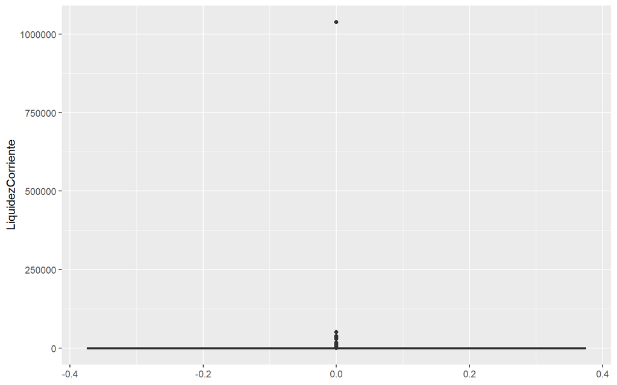

```r
empresas_3 %>%
  ggplot(aes(y = LiquidezCorriente)) +
  geom_boxplot()
```

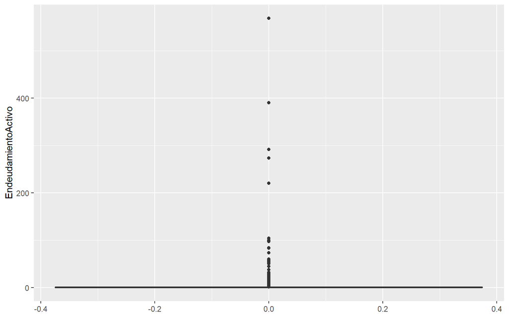

```r
empresas_3 %>%
  ggplot(aes(y = EndeudamientoActivo)) +
  geom_boxplot()
```

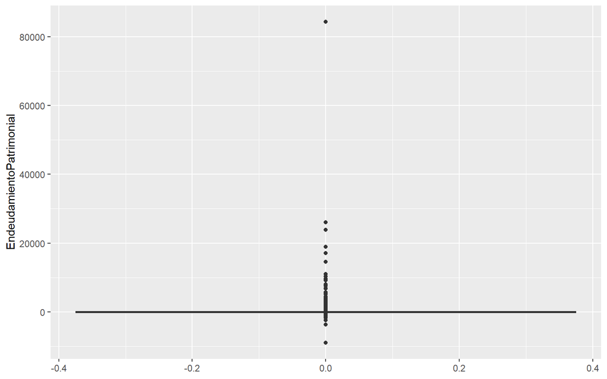

```r
empresas_3 %>%
  ggplot(aes(y = EndeudamientoPatrimonial)) +
  geom_boxplot()
```

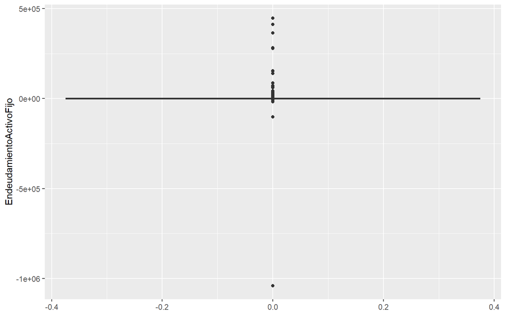

```r
empresas_3 %>%
  ggplot(aes(y = EndeudamientoActivoFijo)) +
  geom_boxplot()
```

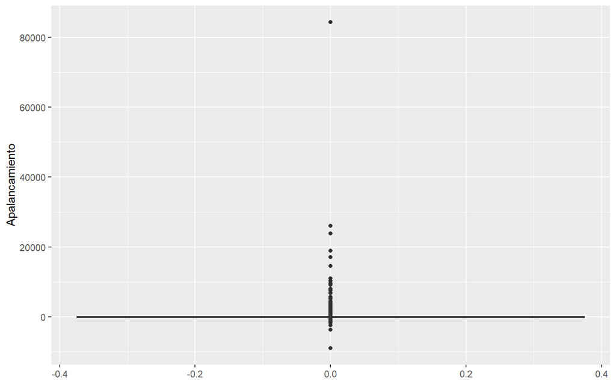

```r
empresas_3 %>%
  ggplot(aes(y = Apalancamiento)) +
  geom_boxplot()
```

La función siguiente cuenta con dos parámetros de entrada: el dataframe y las variables para las cuales deseamos imputar los valores atípicos. Mediante un bucle for, la función itera sobre cada variable y procede a reemplazar los valores atípicos de las variables numéricas especificadas. Para ello, utiliza el promedio para aquellos valores inferiores al percentil 5 y la mediana para aquellos valores superiores al percentil 95. Al finalizar, la función devuelve un dataframe actualizado, eliminando así los datos atípicos presentes en las variables señaladas.

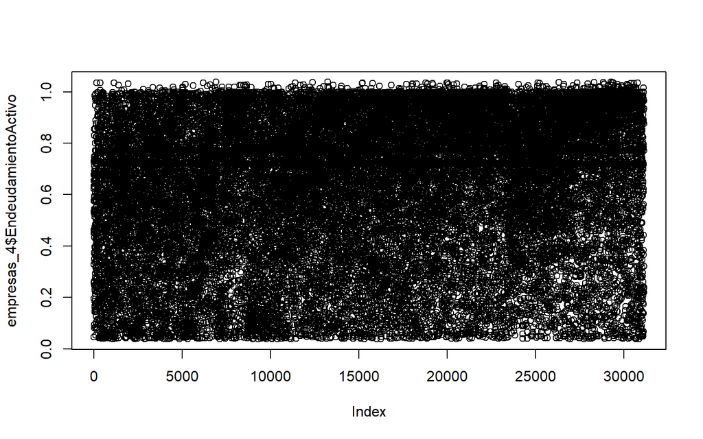

```r
impute_outliers <- function(dataframe, variables) {
  for (var in variables) {
    dataframe[[var]][dataframe[[var]] < quantile(dataframe[[var]], 0.05, na.rm = TRUE)] <- mean(dataframe[[var]], na.rm = TRUE)
    dataframe[[var]][dataframe[[var]] > quantile(dataframe[[var]], 0.95, na.rm = TRUE)] <- median(dataframe[[var]], na.rm = TRUE)
  }
  return(dataframe)
}
columnas_a_imputar <- c("LiquidezCorriente", "EndeudamientoActivo","EndeudamientoPatrimonial",
                        "EndeudamientoActivoFijo", "Apalancamiento")

empresas_4 <- impute_outliers(empresas_3, columnas_a_imputar)
plot(empresas_4$EndeudamientoActivo)
```

La gráfica anterior corrobora que existe una dispersión adecuada de datos.

## Análisis

#### Crea una tabla resumiendo el número total de empresas por actividad económica y por actividad económica por cada cantón. La tabla simplemente debe aparecer como un data frame o tibble en tu script.

```r
#total empresas por actividad económica y por cantón
# Resumen del número total de empresas por actividad económica
resumen_actividad_economica <- empresas_4 %>%
  group_by(Actividad_economica) %>%
  summarise(Total_Empresas = n())
resumen_actividad_economica
```

```
## # A tibble: 20 × 2
##    Actividad_economica Total_Empresas
##    <fct>                        <int>
##  1 A                             2213
##  2 B                              336
##  3 C                             2799
##  4 D                              132
##  5 E                              121
##  6 F                             2407
##  7 G                             8210
##  8 H                             2773
##  9 I                              726
## 10 J                             1069
## 11 K                              502
## 12 L                             3439
## 13 M                             3296
## 14 N                             2028
## 15 O                                5
## 16 P                              380
## 17 Q                              406
## 18 R                               94
## 19 S                              186
## 20 Z                                1
```

```r
# Resumen del número total de empresas por actividad económica y por cantón
resumen_actividad_canton <- empresas_4 %>%
  group_by(Actividad_economica, Canton) %>%
  summarise(Total_Empresas = n())
resumen_actividad_canton
```

```
## # A tibble: 1,025 × 3
## # Groups:   Actividad_economica [20]
##    Actividad_economica Canton       Total_Empresas
##    <fct>               <chr>                 <int>
##  1 A                   AMBATO                    7
##  2 A                   ANTONIO ANTE              1
##  3 A                   ARCHIDONA                 2
##  4 A                   ARENILLAS                 2
##  5 A                   BABA                      7
##  6 A                   BABAHOYO                 12
##  7 A                   BALAO                     1
##  8 A                   BALSAS                    2
##  9 A                   BALZAR                    6
## 10 A                   BOLÍVAR                   2
## # ℹ 1,015 more rows
```

####Gráficamente muestra el comparativo de los indicadores financieros de liquidez y solvencia por Status y provincia.

[output not shown]

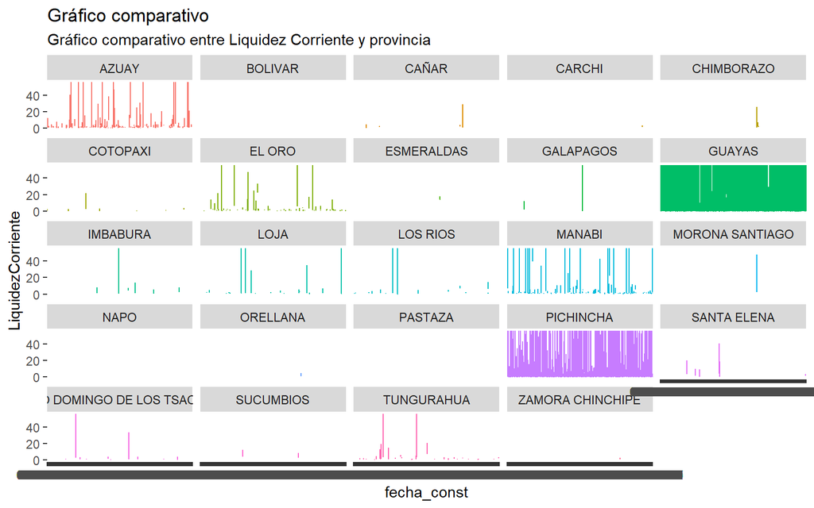

```r
#Graficar liquidez por status y provincia
#solo Status=ACTIVA
#liquidez
empresas_activa<- empresas_4 %>% filter(Status=="ACTIVA")
ggplot(empresas_activa, aes(x=fecha_const,  y = LiquidezCorriente, color= Provincia)) +
  geom_line() +
  labs(title = "Gráfico comparativo",
       subtitle = "Gráfico comparativo entre Liquidez Corriente y provincia")+
  facet_wrap(~Provincia)+
  theme_grey()+
  theme(legend.position = "none")
```

[output not shown]

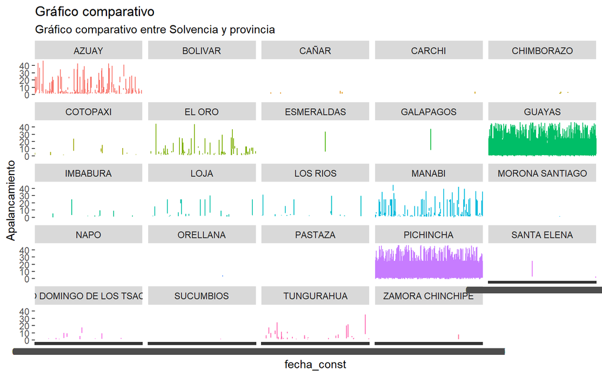

```r
#solvencia
ggplot(empresas_activa, aes(x=fecha_const,  y = Apalancamiento, color= Provincia)) +
  geom_line() +
  labs(title = "Gráfico comparativo",
       subtitle = "Gráfico comparativo entre Solvencia y provincia")+
  facet_wrap(~Provincia)+
  theme_grey()+
  theme(legend.position = "none")
```

**Filtrado de Datos**:

El código comienza filtrando las empresas que tienen un estado “ACTIVA” del tibble “empresas_4” y crea un nuevo tibble llamado “empresas_activa”. Gráfico Comparativo de Liquidez: Utilizando ggplot, se creó un gráfico de líneas para comparar la evolución de la liquidez corriente a lo largo del tiempo. El eje x representa la fecha de constitución (“fecha_const”), el eje y muestra el valor de la liquidez corriente (“LiquidezCorriente”), y el color de las líneas varía según la provincia a la que pertenecen las empresas. El gráfico se presenta con un título (“Gráfico comparativo”) y un subtítulo (“Gráfico comparativo entre Liquidez Corriente y provincia”). Además, se utiliza facet_wrap() para dividir el gráfico en múltiples paneles, uno por cada provincia. La función theme_grey() ajusta el aspecto visual del gráfico y theme(legend.position = “none”) oculta la leyenda.

**Comentarios:**

El código busca visualizar la liquidez corriente a lo largo del tiempo para empresas “ACTIVAS”, pero esta vez desglosado por provincia. El uso de facet_wrap() permite comparar cómo varía la liquidez corriente en diferentes provincias de manera más clara al mostrar cada provincia en su propio panel. Cómo podemos observar tenemos 5 provincias con mayor liquidez corriente las cuales son:

• Guayas • Pichincha • Manabí • Azuay • El Oro

El código tuvo como objetivo crear una gráfica comparativa de solvencia (medida a través del indicador de apalancamiento) por estado (“Status”) y provincia para empresas con estado “ACTIVA”.

**SOLVENCIA** **Análisis del Código:**

**Filtrado de Datos:**

El código comienza filtrando las empresas que tienen un estado “ACTIVA” del tibble “empresas_4” y crea un nuevo tibble llamado “empresas_activa”.

*Gráfico Comparativo de Solvencia:*

Utilizando ggplot, se crea un gráfico de líneas para comparar la evolución del apalancamiento financiero (solvencia) a lo largo del tiempo. El eje x representa la fecha de constitución (“fecha_const”), el eje y muestra el valor del apalancamiento (“Apalancamiento”), y el color de las líneas varía según la provincia a la que pertenecen las empresas. El gráfico se presenta con un título (“Gráfico comparativo”) y un subtítulo (“Gráfico comparativo entre Solvencia y provincia”). Además, se utiliza facet_wrap() para dividir el gráfico en múltiples paneles, uno por cada provincia. La función theme_grey() ajusta el aspecto visual del gráfico y theme(legend.position = “none”) oculta la leyenda.

**Comentarios:**

Este código es similar al fragmento anterior, pero en lugar de analizar la liquidez corriente, está enfocado en la solvencia, representada por el indicador de apalancamiento.

Al igual que en el análisis de la liquidez corriente, el uso de facet_wrap() permite comparar cómo varía la solvencia en diferentes provincias, lo que puede ser útil para identificar patrones o tendencias en la solvencia de las empresas.

Cada línea representa una provincia y muestra las fluctuaciones en el indicador de apalancamiento. Los paneles separados por provincia permiten una comparación más detallada entre las diferentes regiones. La leyenda se ha ocultado en este caso para evitar la sobrecarga visual y mantener el foco en los datos principales. Y cómo podemos visualizar, reflejan 5 provincias con mayor solvencia las cuales son: • Guayas • Pichincha • Manabí • Azuay • El Oro

Lo que permite conocer que las mismas provincias se mantienen con el mayor índice tanto en “Liquidez Corriente” como en “Solvencia”.

#### Gráficamente muestra el comparativo de los indicadores financieros de liquidez y solvencia por tipo de empresa.

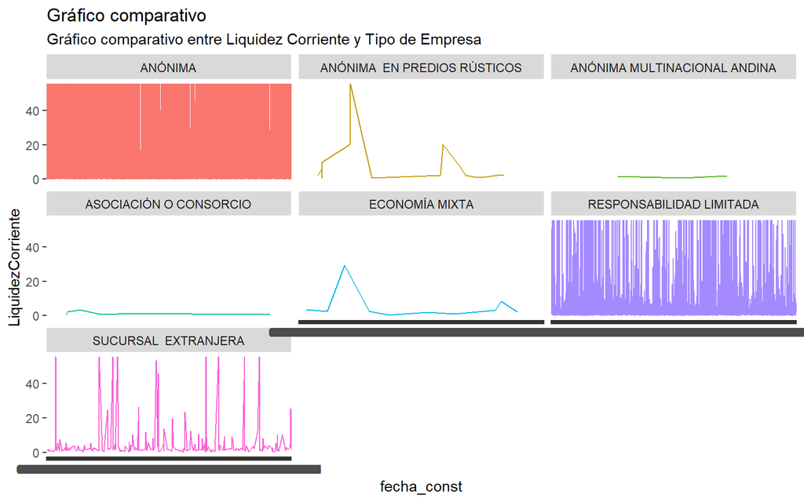

```r
#Graficar liquidez por status y tipo de empresa
#liquidez
ggplot(empresas_activa, aes(x=fecha_const,  y = LiquidezCorriente, color= TipoEmpresa, group=TipoEmpresa)) +
  geom_line() +
  labs(title = "Gráfico comparativo",
       subtitle = "Gráfico comparativo entre Liquidez Corriente y Tipo de Empresa")+
  facet_wrap(~TipoEmpresa)+
  theme_grey()+
  theme(legend.position = "none")
```

[figure not shown]

```r
#solvencia
ggplot(empresas_activa, aes(x=fecha_const,  y = Apalancamiento, color= TipoEmpresa, group=TipoEmpresa)) +
  geom_line() +
  labs(title = "Gráfico comparativo",
       subtitle = "Gráfico comparativo entre Liquidez Corriente y Tipo de Empresa")+
  facet_wrap(~TipoEmpresa)+
  theme_grey()+
  theme(legend.position = "none")
```

El código suministrado tiene como finalidad crear un gráfico comparativo de los indicadores financieros de liquidez corriente por tipo de empresa a lo largo del tiempo.

**Análisis del Código:**

*Filtrado de Datos:*

En el script se comienza filtrando y seleccionando las empresas con estado “ACTIVA” del conjunto de datos “empresas_activa”. Esto implica que solo se considerarán las empresas actualmente operativas para el análisis.

*Gráfico Comparativo de Liquidez:*

Mediante el paquete ggplot2, se genera un gráfico de líneas que compara la evolución de la liquidez corriente en función de la fecha de constitución (“fecha_const”). El eje x muestra las fechas, el eje y representa los valores de liquidez corriente (“LiquidezCorriente”), y el color de las líneas varía según el tipo de empresa (“TipoEmpresa”). El gráfico se titula “Gráfico comparativo” y se complementa con un subtítulo que indica que se está contrastando la “Liquidez Corriente y Tipo de Empresa”. Se utiliza la función facet_wrap() para separar el gráfico en múltiples paneles, uno para cada tipo de empresa, permitiendo una comparación más precisa. Además, se configura el tema visual del gráfico con theme_grey() y se omite la leyenda mediante theme(legend.position = “none”).

**Comentarios:**

Este código busca proporcionar una visión comparativa de cómo ha evolucionado la liquidez corriente en diferentes tipos de empresas a lo largo del tiempo. El uso de facet_wrap() permite un análisis detallado al presentar cada tipo de empresa en su propio panel. Esto es útil para detectar tendencias o variaciones específicas en la liquidez de distintos tipos de empresas. La comparativa podría revelar patrones generales, como si ciertos tipos de empresas mantienen consistentemente una mayor liquidez que otros o si hay variaciones significativas en períodos específicos. Asimismo, podrían identificarse empresas atípicas que divergen notablemente de la tendencia común, lo que podría indicar circunstancias financieras únicas. En resumen, el análisis visual ofrece una perspectiva rápida y efectiva de la evolución de la liquidez corriente en función del tipo de empresa, ayudando a tomar decisiones informadas sobre la gestión financiera y a identificar áreas que requieran mayor atención.

Se tuvo como objetivo crear un gráfico comparativo de los indicadores financieros de solvencia (medidos a través del indicador de apalancamiento) por tipo de empresa a lo largo del tiempo.

**Análisis del Código:**

*Selección de Datos:*

Se utiliza el conjunto de datos “empresas_activa” para generar el gráfico. Las empresas consideradas son aquellas que tienen un estado “ACTIVA”.

*Gráfico Comparativo de Solvencia:*

**Comentarios:**

Este código busca proporcionar una representación visual de la evolución del apalancamiento financiero en diferentes tipos de empresas a lo largo del tiempo. La función facet_wrap() facilita la comparación al mostrar cada tipo de empresa en su propio panel, lo que permite identificar tendencias específicas y variaciones en el apalancamiento. Al igual que en el análisis anterior, este gráfico podría revelar patrones importantes, acerca de si ciertos tipos de empresas han mantenido un apalancamiento constante o si ha habido fluctuaciones significativas en el apalancamiento a lo largo del tiempo. También podría ayudar a identificar posibles correlaciones entre el apalancamiento y otros factores financieros o económicos. Permitiendo un análisis visual brindando información valiosa sobre cómo la solvencia de diferentes tipos de empresas ha evolucionado a lo largo del tiempo, lo que puede ser útil para la toma de decisiones financieras estratégicas y la identificación de posibles áreas de riesgo o oportunidad.

### Preguntas de Investigación

#### ¿El endeudamiento del activo fue mayor en empresas micro + pequeñas vs. grandes?

```r
pregunta1<-empresas_4 %>% dplyr::group_by(empresas_4$tamanio) %>% summarise(Promedio_Endeudamiento=mean(EndeudamientoActivo, na.rm = TRUE))
```

```r
# pregunta1
#ggplot(pregunta1, aes(x = tamanio, y = Promedio_Endeudamiento, fill = tamanio)) +
#  geom_bar(stat = "identity") +
#  scale_fill_brewer(palette = "Set1") +
#  labs(title = "Promedio del Endeudamiento Activo por Tamaño de Empresa",
#       x = "Tamaño de Empresa",
#       y = "Promedio del Endeudamiento Activo") +
#  theme_minimal()
```

*NOTA: La gráfica en el moduloR_group13script se ejecuta correctamente sin embargo, en el rmakdwon tiene algún tipo de restricción con la librería dplyr o a su vez no reconoce a las variablres que se encuentran dentro de la base con el %>% y por eso se ha omitido en este informe. Su conclusión se basó con la gráfica y la tabla del script.*

#### ¿La liquidez por tipo de compañía es diferente entre aquellas empresas que tienen más de 60 trabajadores directos y que cuenta con 100 a 800 trabajadores administrativos?

```r
#empresas_filtradas <- empresas_4 %>%
 # dplyr:::filter(empresas_4$trabajadores_administrativos >= 100, empresas_4$trabajadores_administrativos <= 800,empresas_4$trabajadores_directo > 60)

#empresas_filtradas

#pregunta2 <- empresas_filtradas %>%
#  dplyr::group_by(empresas_filtradas$TipoEmpresa) %>%
#  summarise(Promedio_Liquidez = mean(LiquidezCorriente, na.rm = FALSE))#liquidez por tipo de empresa
#pregunta2
# ggplot(pregunta2, aes(x = TipoEmpresa, y = Promedio_Liquidez, fill = TipoEmpresa)) +
 # geom_bar(stat = "identity") +
#scale_fill_brewer(palette = "Set1") +
 # labs(title = "Promedio de Liquidez por Tipo de Empresa",
#       x = "Tipo de Empresa",
#       y = "Promedio de Liquidez") +
 # theme_minimal()
```

*NOTA: La gráfica en el moduloR_group13script se ejecuta correctamente sin embargo, en el rmakdwon tiene algún tipo de restricción con la librería dplyr o a su vez no reconoce a las variablres que se encuentran dentro de la base con el %>% y por eso se ha omitido en este informe. Su conclusión se basó con la gráfica y la tabla del script.*

#### Describe el top 10 de empresas con mayor apalancamiento.

```r
top_empresas_apalancamiento <- empresas_4 %>%
  dplyr::arrange(desc(empresas_4$Apalancamiento)) %>%
  head(10)
top_empresas_apalancamiento
```

```
## # A tibble: 10 × 15
##    Empresas Status TipoEmpresa Pais  Provincia Canton Ciudad Actividad_economica
##    <chr>    <fct>  <fct>       <chr> <chr>     <chr>  <chr>  <fct>
##  1 ALIPERR… DISOL… ANÓNIMA     ECUA… GUAYAS    GUAYA… GUAYA… G
##  2 REMBUTS… ACTIVA ANÓNIMA     ECUA… GUAYAS    GUAYA… GUAYA… G
##  3 FRENAUT… ACTIVA RESPONSABI… ECUA… AZUAY     CUENCA CUENCA G
##  4 ECOARQU… DISOL… ANÓNIMA     ECUA… PICHINCHA QUITO  QUITO  F
##  5 DABAEDU… ACTIVA ANÓNIMA     ECUA… SANTA EL… SALIN… JOSÉ … P
##  6 MANCOME… DISOL… ANÓNIMA     ECUA… GUAYAS    GUAYA… GUAYA… L
##  7 CHASECO… ACTIVA RESPONSABI… ECUA… PICHINCHA QUITO  QUITO  J
##  8 KONSAC … ACTIVA ANÓNIMA     ECUA… GUAYAS    GUAYA… GUAYA… N
##  9 BUSINES… ACTIVA RESPONSABI… ECUA… PICHINCHA QUITO  QUITO  G
## 10 DELYNEG… ACTIVA ANÓNIMA     ECUA… GUAYAS    GUAYA… GUAYA… G
## # ℹ 7 more variables: SubActividad <fct>, LiquidezCorriente <dbl>,
## #   EndeudamientoActivo <dbl>, EndeudamientoPatrimonial <dbl>,
## #   EndeudamientoActivoFijo <dbl>, Apalancamiento <dbl>, fecha_const <chr>
```

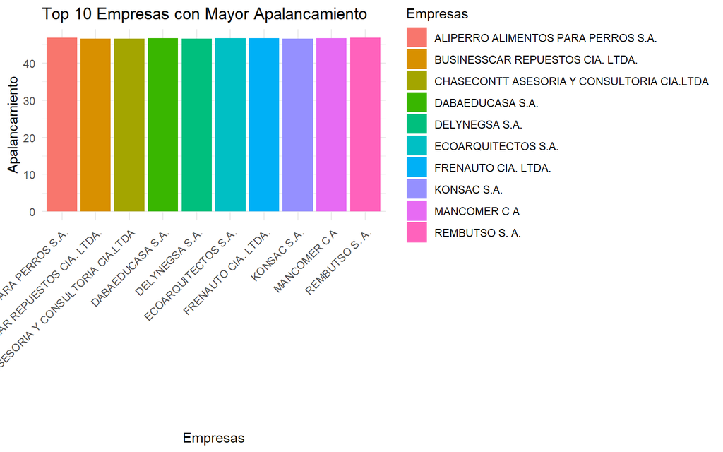

```r
grafico_apalancamiento <- ggplot(top_empresas_apalancamiento, aes(x = Empresas, y = Apalancamiento, fill = Empresas)) +
  geom_bar(stat = "identity") +
 labs(title = "Top 10 Empresas con Mayor Apalancamiento",
       x = "Empresas",
       y = "Apalancamiento") +
 theme_minimal() +
  theme(axis.text.x = element_text(angle = 45, hjust = 1)) +
 scale_fill_discrete(name = "Empresas")
grafico_apalancamiento
```

El gráfico corresponde a las 10 empresas con mayor apalancamiento. Cada barra representará el nivel de apalancamiento de una empresa específica. El eje (x) mostrará el nombre de cada empresa y el eje (y) representará la escala de 0-40 valor del apalancamiento.

## Resumen

Datos cargados:

• balances_2014.xlsx: Datos de balances de empresas en el año 2014.

• cias_codebook.xlsx: Información sobre variables utilizadas en balances_2014.xlsx.

• ciiu.xlsx: Clasificación de la actividad económica según la CIIU.

• Formulario_102.xls: Posible información adicional.

• Liquidez Corriente: Mide la capacidad de la empresa para pagar sus deudas a corto plazo.

• Endeudamiento Activo: Indica cuánto del activo de la empresa está financiado por deuda.

Selección de variables: Del tibble “empresas_1”, se han seleccionado ciertas variables para mantener información relevante sobre las empresas junto con los ratios financieros calculados. Estas variables incluyen nombre de la compañía, situación, tipo de empresa, ubicación geográfica y clasificación de la actividad económica.

1. **Limpieza y preparación de datos**

Se han realizado diversas operaciones para limpiar y preparar los datos para su análisis: - Se convirtieron algunas variables categóricas en factores para facilitar su manejo en análisis posteriores. - Se eliminaron valores infinitos (`-Inf` y `+Inf`) en las variables numéricas, reemplazándolos por valores faltantes (`NA`). - Se eliminaron las filas que contenían valores faltantes (`NA`) en el tibble “empresas_3”. - Se imputaron valores atípicos (outliers) en las variables numéricas seleccionadas en el tibble “empresas_4”. Los valores atípicos se reemplazaron por el valor promedio si eran menores al percentil 5 o por la mediana si eran mayores al percentil 95.